# Unsupervised Learning : Discovering Latent Dimensions using Exploratory Factor Analysis with Extraction and Rotation Method Combinations

John Pauline Pineda

August 10, 2023

# **1. Table of Contents**

## 1.1 Sample Data

The [**JobHiring**](https://real-statistics.com/multivariate-statistics/factor-analysis/factor-analysis-example/) dataset obtained from the [**Statistics By Jim**](https://statisticsbyjim.com/basics/factor-analysis/) website by [Jim Frost](https://statisticsbyjim.com/jim_frost/) was used for this illustrated example.  
Preliminary dataset assessment:  
**[A]** 50 rows (observations)  
**[B]** 12 columns (variables)  
**[B.1]** 12/12 descriptors = 12/12 ordered category  
**[B.1.1]** ACAD (Academic Record)  
**[B.1.2]** APPR (Appearance)  
**[B.1.3]** COMM (Communication)  
**[B.1.4]** CFIT (Company Fit)  
**[B.1.5]** EXPR (Experience)  
**[B.1.6]** JFIT (Job Fit)  
**[B.1.7]** LETT (Cover Letter)  
**[B.1.8]** LIKE (Likeability)  
**[B.1.9]** ORGN (Organization)  
**[B.1.10]** POTL (Potential)  
**[B.1.11]** RESM (Resume)  
**[B.1.12]** SCON (Self-Confidence)

**Code Chunk | Output**

```r
##################################
# Loading R libraries
##################################
library(AppliedPredictiveModeling)
library(performance)
library(parameters)
library(caret)
library(psych)
library(lattice)
library(dplyr)
library(moments)
library(skimr)
library(RANN)
library(pls)
library(corrplot)
library(lares)
library(DMwR)
library(gridExtra)
library(rattle)
library(RColorBrewer)
library(stats)
library(factoextra)
library(FactoMineR)
library(gplots)
library(qgraph)
library(ggplot2)
library(psych)
library(nFactors)
library(MBESS)
library(DandEFA)
library(EFAtools)


##################################
# Loading source and
# formulating the analysis set
##################################
JobHiring <- read.csv("JobHiring.csv",
                   na.strings=c("NA","NaN"," ",""),
                   stringsAsFactors = FALSE)
JobHiring <- as.data.frame(JobHiring)

##################################
# Performing a general exploration of the data set
##################################
dim(JobHiring)
```

```
## [1] 50 12
```

```r
str(JobHiring)
```

```
## 'data.frame':    50 obs. of  12 variables:
##  $ ACAD: int  6 9 6 7 4 7 6 7 9 6 ...
##  $ APPR: int  8 8 7 8 7 7 8 6 8 8 ...
##  $ COMM: int  7 8 7 6 8 7 6 6 8 7 ...
##  $ CFIT: int  5 8 6 5 6 5 7 5 9 8 ...
##  $ EXPR: int  6 10 6 8 6 5 7 8 9 6 ...
##  $ JFIT: int  5 9 7 5 6 6 7 6 8 7 ...
##  $ LETT: int  7 8 7 9 6 5 8 7 10 8 ...
##  $ LIKE: int  7 9 8 8 7 7 7 6 7 7 ...
##  $ ORGN: int  7 8 8 7 8 8 5 5 8 8 ...
##  $ POTL: int  6 9 6 8 5 7 7 7 8 6 ...
##  $ RESM: int  7 9 6 7 4 4 8 6 9 7 ...
##  $ SCON: int  7 9 8 7 6 6 7 6 8 7 ...
```

```r
summary(JobHiring)
```

```
##       ACAD            APPR            COMM            CFIT
##  Min.   : 4.00   Min.   : 5.00   Min.   : 3.00   Min.   : 3.00
##  1st Qu.: 6.25   1st Qu.: 7.00   1st Qu.: 6.00   1st Qu.: 6.00
##  Median : 7.00   Median : 7.50   Median : 7.00   Median : 7.00
##  Mean   : 7.40   Mean   : 7.44   Mean   : 6.86   Mean   : 6.88
##  3rd Qu.: 8.00   3rd Qu.: 8.00   3rd Qu.: 8.00   3rd Qu.: 8.00
##  Max.   :10.00   Max.   :10.00   Max.   :10.00   Max.   :10.00
##       EXPR            JFIT            LETT            LIKE           ORGN
##  Min.   : 5.00   Min.   : 3.00   Min.   : 4.00   Min.   :4.00   Min.   :3.00
##  1st Qu.: 6.00   1st Qu.: 6.00   1st Qu.: 6.00   1st Qu.:7.00   1st Qu.:5.25
##  Median : 7.00   Median : 7.00   Median : 7.00   Median :7.50   Median :7.00
##  Mean   : 7.32   Mean   : 7.02   Mean   : 7.22   Mean   :7.38   Mean   :6.86
##  3rd Qu.: 8.00   3rd Qu.: 8.00   3rd Qu.: 8.00   3rd Qu.:8.00   3rd Qu.:8.00
##  Max.   :10.00   Max.   :10.00   Max.   :10.00   Max.   :9.00   Max.   :9.00
##       POTL           RESM            SCON
##  Min.   : 4.0   Min.   : 4.00   Min.   :5.00
##  1st Qu.: 6.0   1st Qu.: 6.00   1st Qu.:7.00
##  Median : 7.5   Median : 7.00   Median :7.00
##  Mean   : 7.3   Mean   : 7.24   Mean   :7.34
##  3rd Qu.: 8.0   3rd Qu.: 9.00   3rd Qu.:8.00
##  Max.   :10.0   Max.   :10.00   Max.   :9.00
```

```r
##################################
# Formulating a data type assessment summary
##################################
PDA <- JobHiring
(PDA.Summary <- data.frame(
  Column.Index=c(1:length(names(PDA))),
  Column.Name= names(PDA),
  Column.Type=sapply(PDA, function(x) class(x)),
  row.names=NULL)
)
```

```
##    Column.Index Column.Name Column.Type
## 1             1        ACAD     integer
## 2             2        APPR     integer
## 3             3        COMM     integer
## 4             4        CFIT     integer
## 5             5        EXPR     integer
## 6             6        JFIT     integer
## 7             7        LETT     integer
## 8             8        LIKE     integer
## 9             9        ORGN     integer
## 10           10        POTL     integer
## 11           11        RESM     integer
## 12           12        SCON     integer
```

## 1.2 Data Quality Assessment

Data quality assessment:  
**[A]** No missing observations noted for any variable.  
**[B]** No low variance observed for any variable with First.Second.Mode.Ratio>5.  
**[C]** No low variance observed for any variable with Unique.Count.Ratio<0.01.  
**[D]** No high skewness observed for any variable with Skewness>3 or Skewness<(-3).

**Code Chunk | Output**

```r
##################################
# Loading dataset
##################################
DQA <- JobHiring

##################################
# Formulating an overall data quality assessment summary
##################################
(DQA.Summary <- data.frame(
  Column.Name= names(DQA),
  Column.Type=sapply(DQA, function(x) class(x)),
  Row.Count=sapply(DQA, function(x) nrow(DQA)),
  NA.Count=sapply(DQA,function(x)sum(is.na(x))),
  Fill.Rate=sapply(DQA,function(x)format(round((sum(!is.na(x))/nrow(DQA)),3),nsmall=3)),
  row.names=NULL)
)
```

```
##    Column.Name Column.Type Row.Count NA.Count Fill.Rate
## 1         ACAD     integer        50        0     1.000
## 2         APPR     integer        50        0     1.000
## 3         COMM     integer        50        0     1.000
## 4         CFIT     integer        50        0     1.000
## 5         EXPR     integer        50        0     1.000
## 6         JFIT     integer        50        0     1.000
## 7         LETT     integer        50        0     1.000
## 8         LIKE     integer        50        0     1.000
## 9         ORGN     integer        50        0     1.000
## 10        POTL     integer        50        0     1.000
## 11        RESM     integer        50        0     1.000
## 12        SCON     integer        50        0     1.000
```

```r
##################################
# Listing all descriptors
##################################
DQA.Descriptors <- DQA

##################################
# Listing all numeric Descriptors
##################################
DQA.Descriptors.Numeric <- DQA.Descriptors[,sapply(DQA.Descriptors, is.numeric)]

if (length(names(DQA.Descriptors.Numeric))>0) {
    print(paste0("There are ",
               (length(names(DQA.Descriptors.Numeric))),
               " numeric descriptor variable(s)."))
} else {
  print("There are no numeric descriptor variables.")
}
```

```
## [1] "There are 12 numeric descriptor variable(s)."
```

```r
##################################
# Listing all factor Descriptors
##################################
DQA.Descriptors.Factor <- DQA.Descriptors[,sapply(DQA.Descriptors, is.factor)]

if (length(names(DQA.Descriptors.Factor))>0) {
    print(paste0("There are ",
               (length(names(DQA.Descriptors.Factor))),
               " factor descriptor variable(s)."))
} else {
  print("There are no factor descriptor variables.")
}
```

```
## [1] "There are no factor descriptor variables."
```

```r
##################################
# Formulating a data quality assessment summary for factor Descriptors
##################################
if (length(names(DQA.Descriptors.Factor))>0) {

  ##################################
  # Formulating a function to determine the first mode
  ##################################
  FirstModes <- function(x) {
    ux <- unique(na.omit(x))
    tab <- tabulate(match(x, ux))
    ux[tab == max(tab)]
  }

  ##################################
  # Formulating a function to determine the second mode
  ##################################
  SecondModes <- function(x) {
    ux <- unique(na.omit(x))
    tab <- tabulate(match(x, ux))
    fm = ux[tab == max(tab)]
    sm = x[!(x %in% fm)]
    usm <- unique(sm)
    tabsm <- tabulate(match(sm, usm))
    ifelse(is.na(usm[tabsm == max(tabsm)])==TRUE,
           return("x"),
           return(usm[tabsm == max(tabsm)]))
  }

  (DQA.Descriptors.Factor.Summary <- data.frame(
  Column.Name= names(DQA.Descriptors.Factor),
  Column.Type=sapply(DQA.Descriptors.Factor, function(x) class(x)),
  Unique.Count=sapply(DQA.Descriptors.Factor, function(x) length(unique(x))),
  First.Mode.Value=sapply(DQA.Descriptors.Factor, function(x) as.character(FirstModes(x)[1])),
  Second.Mode.Value=sapply(DQA.Descriptors.Factor, function(x) as.character(SecondModes(x)[1])),
  First.Mode.Count=sapply(DQA.Descriptors.Factor, function(x) sum(na.omit(x) == FirstModes(x)[1])),
  Second.Mode.Count=sapply(DQA.Descriptors.Factor, function(x) sum(na.omit(x) == SecondModes(x)[1])),
  Unique.Count.Ratio=sapply(DQA.Descriptors.Factor, function(x) format(round((length(unique(x))/nrow(DQA.Descriptors.Factor)),3), nsmall=3)),
  First.Second.Mode.Ratio=sapply(DQA.Descriptors.Factor, function(x) format(round((sum(na.omit(x) == FirstModes(x)[1])/sum(na.omit(x) == SecondModes(x)[1])),3), nsmall=3)),
  row.names=NULL)
  )

}

##################################
# Formulating a data quality assessment summary for numeric Descriptors
##################################
if (length(names(DQA.Descriptors.Numeric))>0) {

  ##################################
  # Formulating a function to determine the first mode
  ##################################
  FirstModes <- function(x) {
    ux <- unique(na.omit(x))
    tab <- tabulate(match(x, ux))
    ux[tab == max(tab)]
  }

  ##################################
  # Formulating a function to determine the second mode
  ##################################
  SecondModes <- function(x) {
    ux <- unique(na.omit(x))
    tab <- tabulate(match(x, ux))
    fm = ux[tab == max(tab)]
    sm = na.omit(x)[!(na.omit(x) %in% fm)]
    usm <- unique(sm)
    tabsm <- tabulate(match(sm, usm))
    ifelse(is.na(usm[tabsm == max(tabsm)])==TRUE,
           return(0.00001),
           return(usm[tabsm == max(tabsm)]))
  }

  (DQA.Descriptors.Numeric.Summary <- data.frame(
  Column.Name= names(DQA.Descriptors.Numeric),
  Column.Type=sapply(DQA.Descriptors.Numeric, function(x) class(x)),
  Unique.Count=sapply(DQA.Descriptors.Numeric, function(x) length(unique(x))),
  Unique.Count.Ratio=sapply(DQA.Descriptors.Numeric, function(x) format(round((length(unique(x))/nrow(DQA.Descriptors.Numeric)),3), nsmall=3)),
  First.Mode.Value=sapply(DQA.Descriptors.Numeric, function(x) format(round((FirstModes(x)[1]),3),nsmall=3)),
  Second.Mode.Value=sapply(DQA.Descriptors.Numeric, function(x) format(round((SecondModes(x)[1]),3),nsmall=3)),
  First.Mode.Count=sapply(DQA.Descriptors.Numeric, function(x) sum(na.omit(x) == FirstModes(x)[1])),
  Second.Mode.Count=sapply(DQA.Descriptors.Numeric, function(x) sum(na.omit(x) == SecondModes(x)[1])),
  First.Second.Mode.Ratio=sapply(DQA.Descriptors.Numeric, function(x) format(round((sum(na.omit(x) == FirstModes(x)[1])/sum(na.omit(x) == SecondModes(x)[1])),3), nsmall=3)),
  Minimum=sapply(DQA.Descriptors.Numeric, function(x) format(round(min(x,na.rm = TRUE),3), nsmall=3)),
  Mean=sapply(DQA.Descriptors.Numeric, function(x) format(round(mean(x,na.rm = TRUE),3), nsmall=3)),
  Median=sapply(DQA.Descriptors.Numeric, function(x) format(round(median(x,na.rm = TRUE),3), nsmall=3)),
  Maximum=sapply(DQA.Descriptors.Numeric, function(x) format(round(max(x,na.rm = TRUE),3), nsmall=3)),
  Skewness=sapply(DQA.Descriptors.Numeric, function(x) format(round(skewness(x,na.rm = TRUE),3), nsmall=3)),
  Kurtosis=sapply(DQA.Descriptors.Numeric, function(x) format(round(kurtosis(x,na.rm = TRUE),3), nsmall=3)),
  Percentile25th=sapply(DQA.Descriptors.Numeric, function(x) format(round(quantile(x,probs=0.25,na.rm = TRUE),3), nsmall=3)),
  Percentile75th=sapply(DQA.Descriptors.Numeric, function(x) format(round(quantile(x,probs=0.75,na.rm = TRUE),3), nsmall=3)),
  row.names=NULL)
  )

}
```

```
##    Column.Name Column.Type Unique.Count Unique.Count.Ratio First.Mode.Value
## 1         ACAD     integer            7              0.140            7.000
## 2         APPR     integer            6              0.120            8.000
## 3         COMM     integer            8              0.160            7.000
## 4         CFIT     integer            8              0.160            8.000
## 5         EXPR     integer            6              0.120            8.000
## 6         JFIT     integer            7              0.140            7.000
## 7         LETT     integer            7              0.140            8.000
## 8         LIKE     integer            6              0.120            8.000
## 9         ORGN     integer            7              0.140            7.000
## 10        POTL     integer            7              0.140            8.000
## 11        RESM     integer            7              0.140            9.000
## 12        SCON     integer            5              0.100            7.000
##    Second.Mode.Value First.Mode.Count Second.Mode.Count First.Second.Mode.Ratio
## 1              8.000               14                12                   1.167
```

[output cut: 24 more lines]

```r
##################################
# Identifying potential data quality issues
##################################

##################################
# Checking for missing observations
##################################
if ((nrow(DQA.Summary[DQA.Summary$NA.Count>0,]))>0){
  print(paste0("Missing observations noted for ",
               (nrow(DQA.Summary[DQA.Summary$NA.Count>0,])),
               " variable(s) with NA.Count>0 and Fill.Rate<1.0."))
  DQA.Summary[DQA.Summary$NA.Count>0,]
} else {
  print("No missing observations noted.")
}
```

```
## [1] "No missing observations noted."
```

```r
##################################
# Checking for zero or near-zero variance Descriptors
##################################
if (length(names(DQA.Descriptors.Factor))==0) {
  print("No factor descriptors noted.")
} else if (nrow(DQA.Descriptors.Factor.Summary[as.numeric(as.character(DQA.Descriptors.Factor.Summary$First.Second.Mode.Ratio))>5,])>0){
  print(paste0("Low variance observed for ",
               (nrow(DQA.Descriptors.Factor.Summary[as.numeric(as.character(DQA.Descriptors.Factor.Summary$First.Second.Mode.Ratio))>5,])),
               " factor variable(s) with First.Second.Mode.Ratio>5."))
  DQA.Descriptors.Factor.Summary[as.numeric(as.character(DQA.Descriptors.Factor.Summary$First.Second.Mode.Ratio))>5,]
} else {
  print("No low variance factor descriptors due to high first-second mode ratio noted.")
}
```

```
## [1] "No factor descriptors noted."
```

```r
if (length(names(DQA.Descriptors.Numeric))==0) {
  print("No numeric descriptors noted.")
} else if (nrow(DQA.Descriptors.Numeric.Summary[as.numeric(as.character(DQA.Descriptors.Numeric.Summary$First.Second.Mode.Ratio))>5,])>0){
  print(paste0("Low variance observed for ",
               (nrow(DQA.Descriptors.Numeric.Summary[as.numeric(as.character(DQA.Descriptors.Numeric.Summary$First.Second.Mode.Ratio))>5,])),
               " numeric variable(s) with First.Second.Mode.Ratio>5."))
  DQA.Descriptors.Numeric.Summary[as.numeric(as.character(DQA.Descriptors.Numeric.Summary$First.Second.Mode.Ratio))>5,]
} else {
  print("No low variance numeric descriptors due to high first-second mode ratio noted.")
}
```

```
## [1] "No low variance numeric descriptors due to high first-second mode ratio noted."
```

```r
if (length(names(DQA.Descriptors.Numeric))==0) {
  print("No numeric descriptors noted.")
} else if (nrow(DQA.Descriptors.Numeric.Summary[as.numeric(as.character(DQA.Descriptors.Numeric.Summary$Unique.Count.Ratio))<0.01,])>0){
  print(paste0("Low variance observed for ",
               (nrow(DQA.Descriptors.Numeric.Summary[as.numeric(as.character(DQA.Descriptors.Numeric.Summary$Unique.Count.Ratio))<0.01,])),
               " numeric variable(s) with Unique.Count.Ratio<0.01."))
  DQA.Descriptors.Numeric.Summary[as.numeric(as.character(DQA.Descriptors.Numeric.Summary$Unique.Count.Ratio))<0.01,]
} else {
  print("No low variance numeric descriptors due to low unique count ratio noted.")
}
```

```
## [1] "No low variance numeric descriptors due to low unique count ratio noted."
```

```r
##################################
# Checking for skewed Descriptors
##################################
if (length(names(DQA.Descriptors.Numeric))==0) {
  print("No numeric descriptors noted.")
} else if (nrow(DQA.Descriptors.Numeric.Summary[as.numeric(as.character(DQA.Descriptors.Numeric.Summary$Skewness))>3 |
                                               as.numeric(as.character(DQA.Descriptors.Numeric.Summary$Skewness))<(-3),])>0){
  print(paste0("High skewness observed for ",
  (nrow(DQA.Descriptors.Numeric.Summary[as.numeric(as.character(DQA.Descriptors.Numeric.Summary$Skewness))>3 |
                                               as.numeric(as.character(DQA.Descriptors.Numeric.Summary$Skewness))<(-3),])),
  " numeric variable(s) with Skewness>3 or Skewness<(-3)."))
  DQA.Descriptors.Numeric.Summary[as.numeric(as.character(DQA.Descriptors.Numeric.Summary$Skewness))>3 |
                                 as.numeric(as.character(DQA.Descriptors.Numeric.Summary$Skewness))<(-3),]
} else {
  print("No skewed numeric descriptors noted.")
}
```

```
## [1] "No skewed numeric descriptors noted."
```

## 1.3 Data Preprocessing

### 1.3.1 Outlier Detection

**Code Chunk | Output**

```r
##################################
# Loading dataset
##################################
DPA <- JobHiring

##################################
# Gathering descriptive statistics
##################################
(DPA_Skimmed <- skim(DPA))
```

Data summary

| Name | DPA |
| --- | --- |
| Number of rows | 50 |
| Number of columns | 12 |
| _______________________ |  |
| Column type frequency: |  |
| numeric | 12 |
| ________________________ |  |
| Group variables | None |

**Variable type: numeric**

| skim_variable | n_missing | complete_rate | mean | sd | p0 | p25 | p50 | p75 | p100 | hist |
| --- | --- | --- | --- | --- | --- | --- | --- | --- | --- | --- |
| ACAD | 0 | 1 | 7.40 | 1.29 | 4 | 6.25 | 7.0 | 8 | 10 | ▁▆▇▇▆ |
| APPR | 0 | 1 | 7.44 | 1.01 | 5 | 7.00 | 7.5 | 8 | 10 | ▃▇▇▂▁ |
| COMM | 0 | 1 | 6.86 | 1.47 | 3 | 6.00 | 7.0 | 8 | 10 | ▁▁▇▅▁ |
| CFIT | 0 | 1 | 6.88 | 1.62 | 3 | 6.00 | 7.0 | 8 | 10 | ▂▃▇▇▃ |
| EXPR | 0 | 1 | 7.32 | 1.36 | 5 | 6.00 | 7.0 | 8 | 10 | ▇▆▆▅▁ |
| JFIT | 0 | 1 | 7.02 | 1.60 | 3 | 6.00 | 7.0 | 8 | 10 | ▁▁▇▃▂ |
| LETT | 0 | 1 | 7.22 | 1.67 | 4 | 6.00 | 7.0 | 8 | 10 | ▆▅▇▇▇ |
| LIKE | 0 | 1 | 7.38 | 1.12 | 4 | 7.00 | 7.5 | 8 | 9 | ▁▂▇▇▃ |
| ORGN | 0 | 1 | 6.86 | 1.58 | 3 | 5.25 | 7.0 | 8 | 9 | ▁▃▂▅▇ |
| POTL | 0 | 1 | 7.30 | 1.39 | 4 | 6.00 | 7.5 | 8 | 10 | ▂▅▆▇▅ |
| RESM | 0 | 1 | 7.24 | 1.68 | 4 | 6.00 | 7.0 | 9 | 10 | ▃▆▅▅▇ |
| SCON | 0 | 1 | 7.34 | 1.17 | 5 | 7.00 | 7.0 | 8 | 9 | ▂▃▇▇▅ |

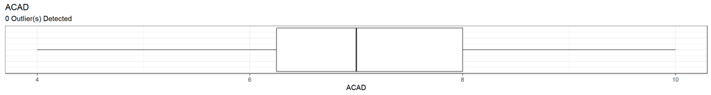

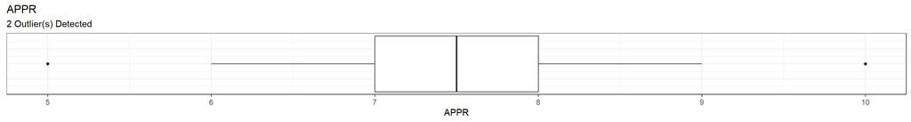

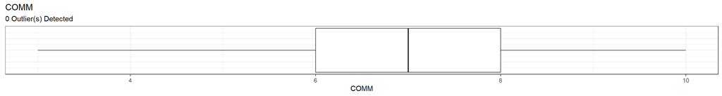

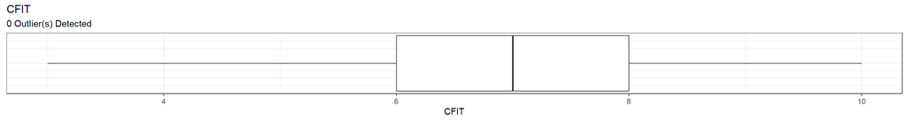

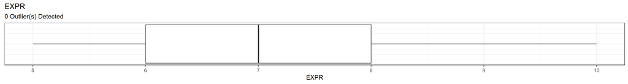

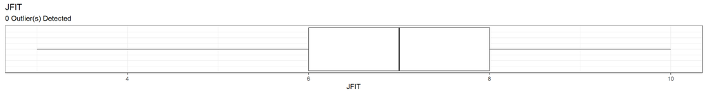

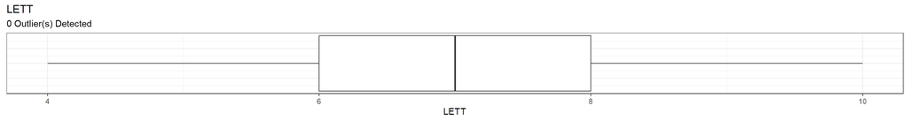

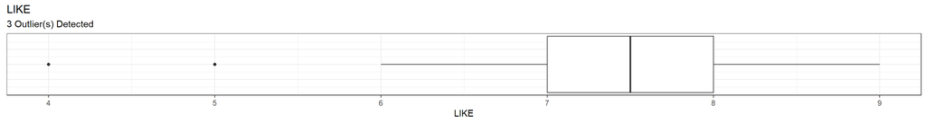

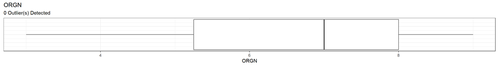

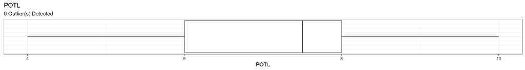

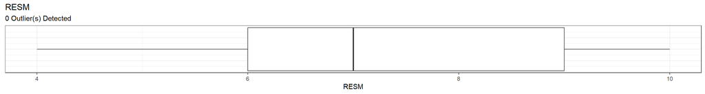

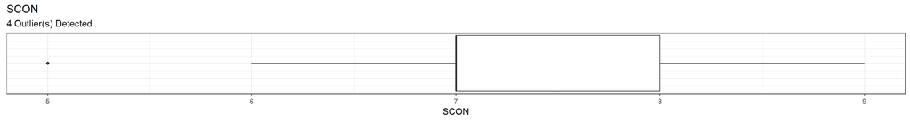

```r
##################################
# Outlier Detection
##################################

##################################
# Listing all Descriptors
##################################
DPA.Descriptors <- DPA

##################################
# Listing all numeric Descriptors
##################################
DPA.Descriptors.Numeric <- DPA.Descriptors[,sapply(DPA.Descriptors, is.numeric)]

##################################
# Identifying outliers for the numeric Descriptors
##################################
OutlierCountList <- c()

for (i in 1:ncol(DPA.Descriptors.Numeric)) {
  Outliers <- boxplot.stats(DPA.Descriptors.Numeric[,i])$out
  OutlierCount <- length(Outliers)
  OutlierCountList <- append(OutlierCountList,OutlierCount)
  OutlierIndices <- which(DPA.Descriptors.Numeric[,i] %in% c(Outliers))
  print(
  ggplot(DPA.Descriptors.Numeric, aes(x=DPA.Descriptors.Numeric[,i])) +
  geom_boxplot() +
  theme_bw() +
  theme(axis.text.y=element_blank(),
        axis.ticks.y=element_blank()) +
  xlab(names(DPA.Descriptors.Numeric)[i]) +
  labs(title=names(DPA.Descriptors.Numeric)[i],
       subtitle=paste0(OutlierCount, " Outlier(s) Detected")))
}
```

### 1.3.2 Zero and Near-Zero Variance

**Code Chunk | Output**

```r
##################################
# Zero and Near-Zero Variance
##################################

##################################
# Identifying columns with low variance
###################################
DPA_LowVariance <- nearZeroVar(DPA,
                               freqCut = 80/20,
                               uniqueCut = 10,
                               saveMetrics= TRUE)
(DPA_LowVariance[DPA_LowVariance$nzv,])
```

```
## [1] freqRatio     percentUnique zeroVar       nzv
## <0 rows> (or 0-length row.names)
```

```r
if ((nrow(DPA_LowVariance[DPA_LowVariance$nzv,]))==0){

  print("No low variance descriptors noted.")

} else {

  print(paste0("Low variance observed for ",
               (nrow(DPA_LowVariance[DPA_LowVariance$nzv,])),
               " numeric variable(s) with First.Second.Mode.Ratio>4 and Unique.Count.Ratio<0.10."))

  DPA_LowVarianceForRemoval <- (nrow(DPA_LowVariance[DPA_LowVariance$nzv,]))

  print(paste0("Low variance can be resolved by removing ",
               (nrow(DPA_LowVariance[DPA_LowVariance$nzv,])),
               " numeric variable(s)."))

  for (j in 1:DPA_LowVarianceForRemoval) {
  DPA_LowVarianceRemovedVariable <- rownames(DPA_LowVariance[DPA_LowVariance$nzv,])[j]
  print(paste0("Variable ",
               j,
               " for removal: ",
               DPA_LowVarianceRemovedVariable))
  }

  DPA %>%
  skim() %>%
  dplyr::filter(skim_variable %in% rownames(DPA_LowVariance[DPA_LowVariance$nzv,]))

}
```

```
## [1] "No low variance descriptors noted."
```

### 1.3.3 Collinearity

**Code Chunk | Output**

```r
##################################
# Visualizing pairwise correlation between descriptor
##################################
(DPA_Correlation <- cor(DPA.Descriptors.Numeric,
                        method = "pearson",
                        use="pairwise.complete.obs"))
```

```
##           ACAD      APPR      COMM      CFIT      EXPR      JFIT      LETT
## ACAD 1.0000000 0.4701427 0.4054067 0.4992183 0.6672390 0.5393435 0.3269457
## APPR 0.4701427 1.0000000 0.4939720 0.4170806 0.3099465 0.4105762 0.3034917
## COMM 0.4054067 0.4939720 1.0000000 0.5907387 0.1960094 0.5050808 0.4033781
## CFIT 0.4992183 0.4170806 0.5907387 1.0000000 0.3959678 0.8820580 0.4539438
## EXPR 0.6672390 0.3099465 0.1960094 0.3959678 1.0000000 0.5224501 0.4800248
## JFIT 0.5393435 0.4105762 0.5050808 0.8820580 0.5224501 1.0000000 0.4652077
## LETT 0.3269457 0.3034917 0.4033781 0.4539438 0.4800248 0.4652077 1.0000000
## LIKE 0.3990134 0.6392098 0.4900438 0.4842812 0.3058838 0.5305521 0.3572902
## ORGN 0.3578991 0.5370193 0.8617976 0.6223051 0.1732109 0.5274873 0.3372713
## POTL 0.7951979 0.5133541 0.4206029 0.6586426 0.7035542 0.7057635 0.3846555
## RESM 0.4606419 0.4986309 0.4255336 0.4432190 0.5172440 0.4607897 0.8368872
## SCON 0.4067717 0.6967065 0.4309427 0.4616973 0.4037882 0.4654267 0.2323177
##           LIKE      ORGN      POTL      RESM      SCON
## ACAD 0.3990134 0.3578991 0.7951979 0.4606419 0.4067717
## APPR 0.6392098 0.5370193 0.5133541 0.4986309 0.6967065
## COMM 0.4900438 0.8617976 0.4206029 0.4255336 0.4309427
## CFIT 0.4842812 0.6223051 0.6586426 0.4432190 0.4616973
## EXPR 0.3058838 0.1732109 0.7035542 0.5172440 0.4037882
## JFIT 0.5305521 0.5274873 0.7057635 0.4607897 0.4654267
## LETT 0.3572902 0.3372713 0.3846555 0.8368872 0.2323177
## LIKE 1.0000000 0.5258919 0.4881676 0.4685663 0.7532282
## ORGN 0.5258919 1.0000000 0.4199960 0.2968767 0.4900298
## POTL 0.4881676 0.4199960 1.0000000 0.4570046 0.5006195
## RESM 0.4685663 0.2968767 0.4570046 1.0000000 0.4334882
## SCON 0.7532282 0.4900298 0.5006195 0.4334882 1.0000000
```

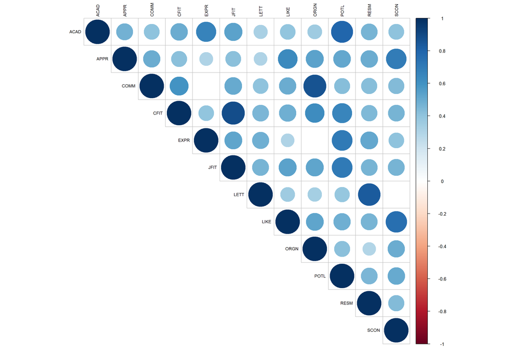

```r
DPA_CorrelationTest <- cor.mtest(DPA.Descriptors.Numeric,
                       method = "pearson",
                       conf.level = 0.95)

corrplot(cor(DPA.Descriptors.Numeric,
             method = "pearson",
             use="pairwise.complete.obs"),
             method = "circle",
             type = "upper",
             order = "original",
             tl.col = "black",
             tl.cex = 0.75,
             tl.srt = 90,
             sig.level = 0.05,
             p.mat = DPA_CorrelationTest$p,
             insig = "blank")
```

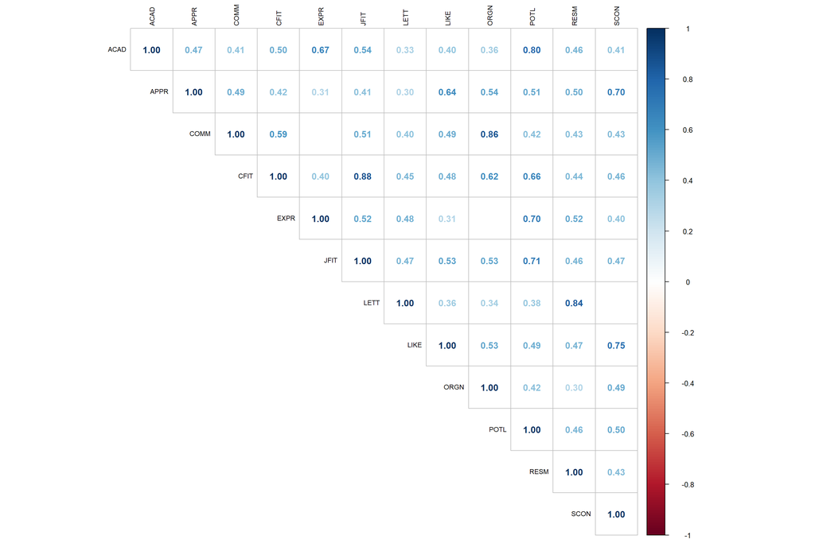

```r
corrplot(cor(DPA.Descriptors.Numeric,
             method = "pearson",
             use="pairwise.complete.obs"),
             method = "number",
             type = "upper",
             order = "original",
             tl.col = "black",
             tl.cex = 0.75,
             tl.srt = 90,
             sig.level = 0.05,
             p.mat = DPA_CorrelationTest$p,
             insig = "blank")
```

```r
##################################
# Identifying the minimally correlated variables
##################################
(DPA_MinimallyCorrelatedCount <- sum(abs(DPA_Correlation[upper.tri(DPA_Correlation)])>0.30))
```

```
## [1] 62
```

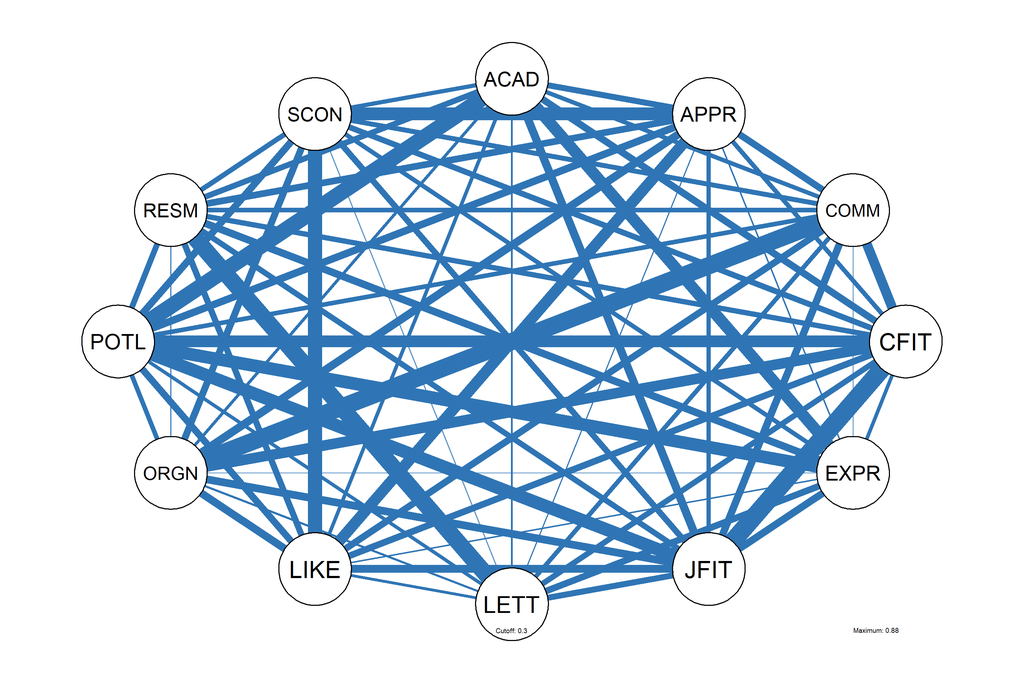

```r
qgraph(cor(DPA.Descriptors.Numeric),
       cut=0.30,
       details=TRUE,
       posCol="#2F75B5",
       negCol="#FF5050",
       labels=names(DPA.Descriptors.Numeric))
```

```r
##################################
# Identifying the highly correlated variables
##################################
(DPA_HighlyCorrelatedCount <- sum(abs(DPA_Correlation[upper.tri(DPA_Correlation)])>0.90))
```

```
## [1] 0
```

```r
if (DPA_HighlyCorrelatedCount > 0) {
  DPA_HighlyCorrelated <- findCorrelation(DPA_Correlation, cutoff = 0.90)

  (DPA_HighlyCorrelatedForRemoval <- length(DPA_HighlyCorrelated))

  print(paste0("High correlation can be resolved by removing ",
               (DPA_HighlyCorrelatedForRemoval),
               " numeric variable(s)."))

  for (j in 1:DPA_HighlyCorrelatedForRemoval) {
  DPA_HighlyCorrelatedRemovedVariable <- colnames(DPA.Predictors.Numeric)[DPA_HighlyCorrelated[j]]
  print(paste0("Variable ",
               j,
               " for removal: ",
               DPA_HighlyCorrelatedRemovedVariable))
  }

}
```

### 1.3.4 Linear Dependency

**Code Chunk | Output**

```r
##################################
# Linear Dependencies
##################################

##################################
# Finding linear dependencies
##################################
DPA_LinearlyDependent <- findLinearCombos(DPA.Descriptors.Numeric)

##################################
# Identifying the linearly dependent variables
##################################
DPA_LinearlyDependent <- findLinearCombos(DPA.Descriptors.Numeric)

(DPA_LinearlyDependentCount <- length(DPA_LinearlyDependent$linearCombos))
```

```
## [1] 0
```

```r
if (DPA_LinearlyDependentCount == 0) {
  print("No linearly dependent predictors noted.")
} else {
  print(paste0("Linear dependency observed for ",
               (DPA_LinearlyDependentCount),
               " subset(s) of numeric variable(s)."))

  for (i in 1:DPA_LinearlyDependentCount) {
    DPA_LinearlyDependentSubset <- colnames(DPA.Predictors.Numeric)[DPA_LinearlyDependent$linearCombos[[i]]]
    print(paste0("Linear dependent variable(s) for subset ",
                 i,
                 " include: ",
                 DPA_LinearlyDependentSubset))
  }

}
```

```
## [1] "No linearly dependent predictors noted."
```

```r
##################################
# Identifying the linearly dependent variables for removal
##################################

if (DPA_LinearlyDependentCount > 0) {
  DPA_LinearlyDependent <- findLinearCombos(DPA.Predictors.Numeric)

  DPA_LinearlyDependentForRemoval <- length(DPA_LinearlyDependent$remove)

  print(paste0("Linear dependency can be resolved by removing ",
               (DPA_LinearlyDependentForRemoval),
               " numeric variable(s)."))

  for (j in 1:DPA_LinearlyDependentForRemoval) {
  DPA_LinearlyDependentRemovedVariable <- colnames(DPA.Predictors.Numeric)[DPA_LinearlyDependent$remove[j]]
  print(paste0("Variable ",
               j,
               " for removal: ",
               DPA_LinearlyDependentRemovedVariable))
  }

}
```

### 1.3.5 Distributional Shape

**Code Chunk | Output**

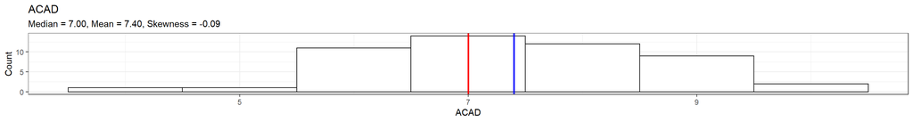

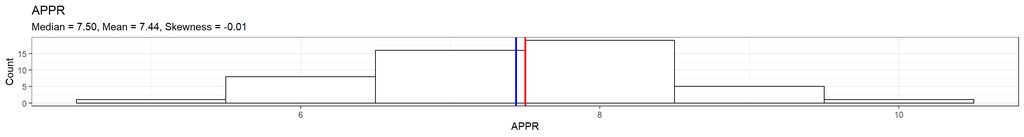

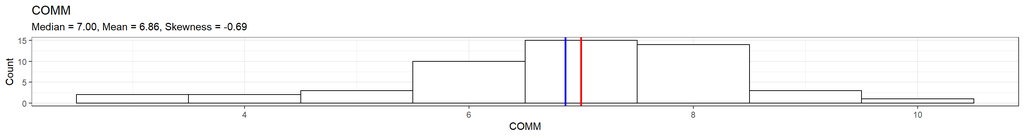

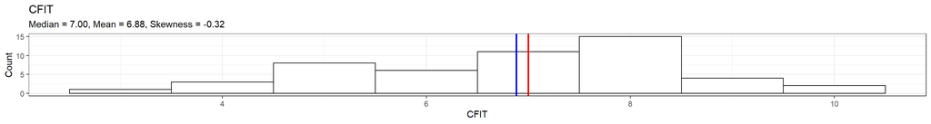

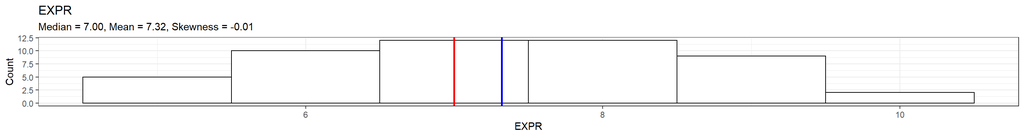

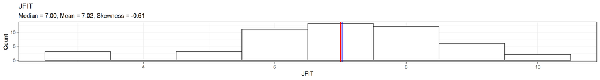

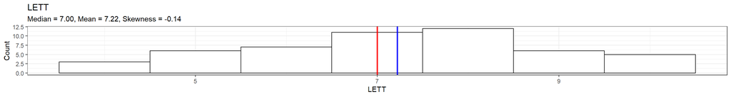

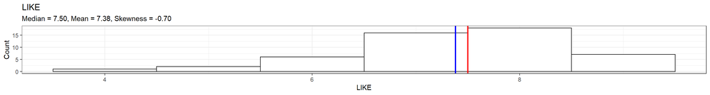

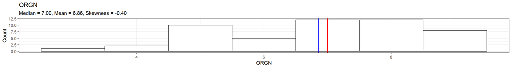

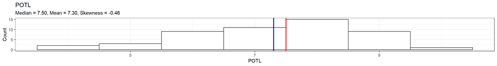

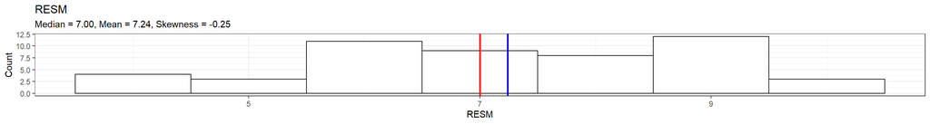

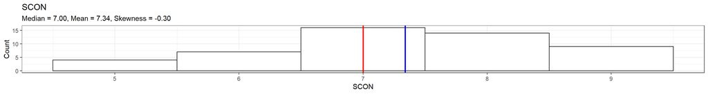

```r
##################################
# Distributional Shape
##################################

##################################
# Formulating the histogram
# for the numeric descriptors
##################################
for (i in 1:ncol(DPA.Descriptors.Numeric)) {
  Median <- format(round(median(DPA.Descriptors.Numeric[,i],na.rm = TRUE),2), nsmall=2)
  Mean <- format(round(mean(DPA.Descriptors.Numeric[,i],na.rm = TRUE),2), nsmall=2)
  Skewness <- format(round(skewness(DPA.Descriptors.Numeric[,i],na.rm = TRUE),2), nsmall=2)
  print(
  ggplot(DPA.Descriptors.Numeric, aes(x=DPA.Descriptors.Numeric[,i])) +
  geom_histogram(binwidth=1,color="black", fill="white") +
  geom_vline(aes(xintercept=mean(DPA.Descriptors.Numeric[,i])),
            color="blue", size=1) +
    geom_vline(aes(xintercept=median(DPA.Descriptors.Numeric[,i])),
            color="red", size=1) +
  theme_bw() +
  ylab("Count") +
  xlab(names(DPA.Descriptors.Numeric)[i]) +
  labs(title=names(DPA.Descriptors.Numeric)[i],
       subtitle=paste0("Median = ", Median,
                       ", Mean = ", Mean,
                       ", Skewness = ", Skewness)))
}
```

## 1.4 Data Pre-Assessment

### 1.4.1 Correlation Matrix Assessment - Determinant Computation

**Code Chunk | Output**

```r
##################################
# Computing the determinant of the correlation matrix
##################################
(DPA_CorrelationMatrixDeterminant <- det(cor(DPA.Descriptors.Numeric)))
```

```
## [1] 2.258001e-05
```

### 1.4.2 Correlation Matrix Assessment - Bartlett’s Test of Sphericity

**Code Chunk | Output**

```r
##################################
# Calculating the Bartlett's Test of Sphericity
##################################
(DPA_BartlettTest <- cortest.bartlett(DPA.Descriptors.Numeric,
                                      n=nrow(DPA.Descriptors.Numeric)))
```

```
## $chisq
## [1] 472.5147
##
## $p.value
## [1] 9.677847e-63
##
## $df
## [1] 66
```

### 1.4.3 Correlation Matrix Assessment - Kaiser-Meyer-Olkin Factor Adequacy

**Code Chunk | Output**

```r
##################################
# Calculating the Kaiser-Meyer-Olkin Factor Adequacy
##################################
(DPA_KMOFactorAdequacy <- KMO(DPA.Descriptors.Numeric))
```

```
##
## -- Kaiser-Meyer-Olkin criterion (KMO) ------------------------------------------
##
## v The overall KMO value for your data is middling.
##   These data are probably suitable for factor analysis.
##
##   Overall: 0.798
##
##   For each variable:
##  ACAD  APPR  COMM  CFIT  EXPR  JFIT  LETT  LIKE  ORGN  POTL  RESM  SCON
## 0.847 0.876 0.790 0.809 0.782 0.827 0.676 0.851 0.740 0.883 0.712 0.777
```

### 1.4.4 Factor Retention - Parallel Analysis

**Code Chunk | Output**

```r
##################################
# Implementing various procedures for determining
# factor retention based on
# the maximum consensus between methods
##################################
(DPA_MethodAgreementProcedure <- parameters::n_factors(DPA.Descriptors.Numeric))
```

```
## # Method Agreement Procedure:
##
## The choice of 4 dimensions is supported by 5 (35.71%) methods out of 14 (Bentler, beta, Parallel analysis, Kaiser criterion, Scree (SE)).
```

```r
as.data.frame(DPA_MethodAgreementProcedure)
```

```
##    n_Factors              Method              Family
## 1          1 Acceleration factor               Scree
## 2          1          Scree (R2)            Scree_SE
## 3          2 Optimal coordinates               Scree
## 4          3                 CNG                 CNG
## 5          4             Bentler             Bentler
## 6          4                beta Multiple_regression
## 7          4   Parallel analysis               Scree
## 8          4    Kaiser criterion               Scree
## 9          4          Scree (SE)            Scree_SE
## 10         6            Bartlett             Barlett
## 11         6                   t Multiple_regression
## 12         6                   p Multiple_regression
## 13         7            Anderson             Barlett
## 14         7              Lawley             Barlett
```

## 1.5 Data Exploration

**Code Chunk | Output**

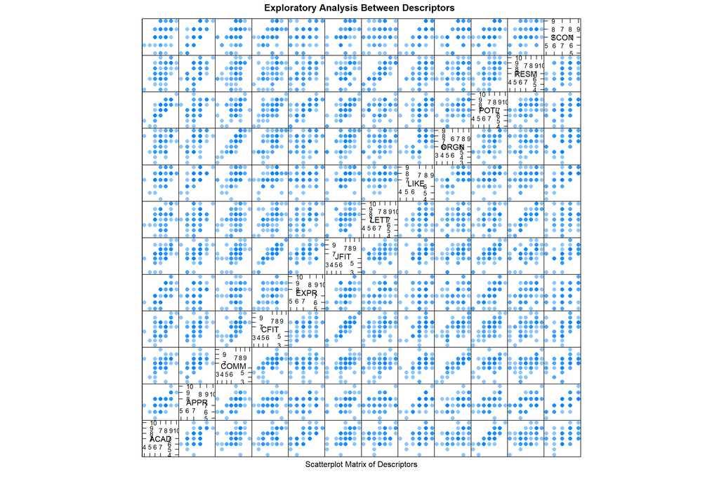

```r
##################################
# Exploratory analysis
# among quantitative descriptors
##################################
splom(~DPA.Descriptors.Numeric,
      pch = 16,
      cex = 1,
      alpha = 0.45,
      auto.key = list(points = TRUE, space = "right"),
      main = "Exploratory Analysis Between Descriptors",
      xlab = "Scatterplot Matrix of Descriptors")
```

## 1.6 Factor Analysis

### 1.6.1 Principal Axes Factor Extraction and Varimax Rotation (FA_PA_V)

**Code Chunk | Output**

```r
##################################
# Conducting exploratory factor analysis
# using Principal Axes extraction
# and Varimax rotation
# with 3 factors
##################################
(FA_PA_V_3F <- fa(DPA.Descriptors.Numeric,
              nfactors = 3,
              fm="pa",
              rotate = "varimax",
              residuals=TRUE,
              SMC=TRUE,
              n.obs=nrow(DPA.Descriptors.Numeric)))
```

```
## Factor Analysis using method =  pa
## Call: fa(r = DPA.Descriptors.Numeric, nfactors = 3, n.obs = nrow(DPA.Descriptors.Numeric),
##     rotate = "varimax", residuals = TRUE, SMC = TRUE, fm = "pa")
## Standardized loadings (pattern matrix) based upon correlation matrix
##       PA1  PA2  PA3   h2   u2 com
## ACAD 0.28 0.74 0.16 0.65 0.35 1.4
## APPR 0.60 0.32 0.18 0.50 0.50 1.7
## COMM 0.79 0.10 0.22 0.69 0.31 1.2
## CFIT 0.60 0.46 0.22 0.61 0.39 2.2
## EXPR 0.05 0.76 0.34 0.69 0.31 1.4
## JFIT 0.52 0.56 0.24 0.64 0.36 2.4
## LETT 0.22 0.20 0.88 0.86 0.14 1.2
## LIKE 0.64 0.31 0.19 0.54 0.46 1.6
## ORGN 0.88 0.09 0.11 0.79 0.21 1.0
## POTL 0.36 0.85 0.14 0.87 0.13 1.4
## RESM 0.28 0.31 0.81 0.83 0.17 1.5
## SCON 0.60 0.37 0.11 0.51 0.49 1.8
##
##                        PA1  PA2  PA3
## SS loadings           3.49 2.85 1.84
## Proportion Var        0.29 0.24 0.15
## Cumulative Var        0.29 0.53 0.68
## Proportion Explained  0.43 0.35 0.22
## Cumulative Proportion 0.43 0.78 1.00
##
## Mean item complexity =  1.6
## Test of the hypothesis that 3 factors are sufficient.
##
## The degrees of freedom for the null model are  66  and the objective function was  10.7 with Chi Square of  472.51
## The degrees of freedom for the model are 33  and the objective function was  2.52
##
## The root mean square of the residuals (RMSR) is  0.07
## The df corrected root mean square of the residuals is  0.1
##
## The harmonic number of observations is  50 with the empirical chi square  35.54  with prob <  0.35
## The total number of observations was  50  with Likelihood Chi Square =  106.33  with prob <  1.2e-09
##
## Tucker Lewis Index of factoring reliability =  0.619
## RMSEA index =  0.21  and the 90 % confidence intervals are  0.168 0.259
## BIC =  -22.76
## Fit based upon off diagonal values = 0.98
## Measures of factor score adequacy
##                                                    PA1  PA2  PA3
## Correlation of (regression) scores with factors   0.94 0.94 0.94
## Multiple R square of scores with factors          0.88 0.88 0.88
## Minimum correlation of possible factor scores     0.76 0.75 0.75
```

```r
(FA_PA_V_3F_Summary <- FA_PA_V_3F %>%
  model_parameters(sort = TRUE, threshold = "max"))
```

```
## # Rotated loadings from Factor Analysis (varimax-rotation)
##
## Variable | PA1  | PA2  | PA3  | Complexity | Uniqueness
## -------------------------------------------------------
## ORGN     | 0.88 |      |      |    1.05    |    0.21
## COMM     | 0.79 |      |      |    1.19    |    0.31
## LIKE     | 0.64 |      |      |    1.65    |    0.46
## APPR     | 0.60 |      |      |    1.72    |    0.50
## SCON     | 0.60 |      |      |    1.76    |    0.49
## CFIT     | 0.60 |      |      |    2.19    |    0.39
## POTL     |      | 0.85 |      |    1.41    |    0.13
## EXPR     |      | 0.76 |      |    1.40    |    0.31
## ACAD     |      | 0.74 |      |    1.40    |    0.35
## JFIT     |      | 0.56 |      |    2.35    |    0.36
## LETT     |      |      | 0.88 |    1.23    |    0.14
## RESM     |      |      | 0.81 |    1.54    |    0.17
##
## The 3 latent factors (varimax rotation) accounted for 68.18% of the total variance of the original data (PA1 = 29.08%, PA2 = 23.78%, PA3 = 15.33%).
```

```r
summary(FA_PA_V_3F_Summary)
```

```
## # (Explained) Variance of Components
##
## Parameter                       |   PA1 |   PA2 |   PA3
## -------------------------------------------------------
## Eigenvalues                     | 6.069 | 1.209 | 0.903
## Variance Explained              | 0.291 | 0.238 | 0.153
## Variance Explained (Cumulative) | 0.291 | 0.529 | 0.682
## Variance Explained (Proportion) | 0.427 | 0.349 | 0.225
```

```r
##################################
# Extracting the residuals
# from the Exploratory Factor Analysis
##################################
(FA_PA_V_3F_Residual <- residuals(FA_PA_V_3F,
                              diag=FALSE,
                              na.rm=TRUE))
```

```
##      ACAD  APPR  COMM  CFIT  EXPR  JFIT  LETT  LIKE  ORGN  POTL  RESM
## ACAD    NA
## APPR  0.03    NA
## COMM  0.07 -0.06    NA
## CFIT -0.04 -0.13  0.02    NA
## EXPR  0.04 -0.02  0.00 -0.06    NA
## JFIT -0.06 -0.12 -0.01  0.27 -0.01    NA
## LETT -0.02 -0.05  0.01  0.04  0.02  0.03    NA
## LIKE -0.04  0.12 -0.09 -0.08 -0.03 -0.02 -0.01    NA
## ORGN  0.03 -0.04  0.13  0.04  0.03  0.00  0.03 -0.08    NA
## POTL  0.04  0.00  0.02  0.03 -0.01  0.01  0.01 -0.03  0.01    NA
## RESM  0.02  0.09 -0.01 -0.05 -0.01 -0.05  0.00  0.04 -0.06 -0.02    NA
## SCON -0.06  0.20 -0.10 -0.09  0.05 -0.08 -0.07  0.24 -0.08 -0.05  0.06
## [1]    NA
```

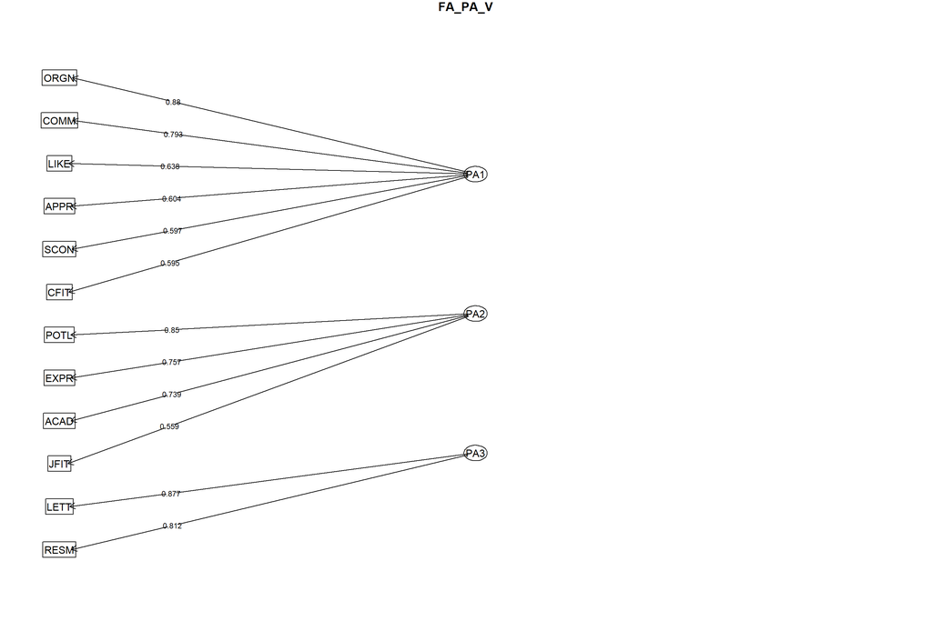

```r
##################################
# Graph the factor loading matrices
##################################
fa.diagram(FA_PA_V_3F,
           sort=TRUE,
           cut=0,
           digits=3,
           main="FA_PA_V",
           cex=0.75)
```

```r
##################################
# computing the internal consistency
# measure of reliability using the
# Cronbach's alpha coefficient
# for each factor
##################################
alpha(DPA.Descriptors.Numeric[,c("ORGN","COMM","LIKE","APPR","SCON","CFIT")])
```

```
##
## Reliability analysis
## Call: alpha(x = DPA.Descriptors.Numeric[, c("ORGN", "COMM", "LIKE",
##     "APPR", "SCON", "CFIT")])
##
##   raw_alpha std.alpha G6(smc) average_r S/N   ase mean  sd median_r
##       0.88      0.89     0.9      0.57 7.8 0.026  7.1 1.1     0.53
##
##     95% confidence boundaries
##          lower alpha upper
## Feldt     0.82  0.88  0.92
## Duhachek  0.83  0.88  0.93
##
##  Reliability if an item is dropped:
##      raw_alpha std.alpha G6(smc) average_r S/N alpha se var.r med.r
## ORGN      0.84      0.86    0.85      0.55 6.0    0.036 0.014  0.49
## COMM      0.85      0.87    0.86      0.56 6.4    0.034 0.012  0.53
## LIKE      0.86      0.86    0.88      0.56 6.4    0.030 0.019  0.52
## APPR      0.86      0.87    0.89      0.57 6.7    0.030 0.019  0.51
## SCON      0.86      0.87    0.87      0.57 6.5    0.029 0.015  0.53
## CFIT      0.87      0.88    0.90      0.59 7.3    0.029 0.020  0.53
##
##  Item statistics
##       n raw.r std.r r.cor r.drop mean  sd
## ORGN 50  0.87  0.84  0.84   0.78  6.9 1.6
## COMM 50  0.84  0.81  0.79   0.74  6.9 1.5
## LIKE 50  0.78  0.81  0.77   0.69  7.4 1.1
## APPR 50  0.75  0.79  0.73   0.67  7.4 1.0
## SCON 50  0.76  0.80  0.76   0.67  7.3 1.2
## CFIT 50  0.78  0.75  0.66   0.64  6.9 1.6
##
## Non missing response frequency for each item
##         3    4    5    6    7    8    9   10 miss
## ORGN 0.02 0.04 0.20 0.10 0.24 0.24 0.16 0.00    0
## COMM 0.04 0.04 0.06 0.20 0.30 0.28 0.06 0.02    0
## LIKE 0.00 0.02 0.04 0.12 0.32 0.36 0.14 0.00    0
## APPR 0.00 0.00 0.02 0.16 0.32 0.38 0.10 0.02    0
## SCON 0.00 0.00 0.08 0.14 0.32 0.28 0.18 0.00    0
## CFIT 0.02 0.06 0.16 0.12 0.22 0.30 0.08 0.04    0
```

```r
alpha(DPA.Descriptors.Numeric[,c("POTL","EXPR","ACAD","JFIT")])
```

```
##
## Reliability analysis
## Call: alpha(x = DPA.Descriptors.Numeric[, c("POTL", "EXPR", "ACAD",
##     "JFIT")])
##
##   raw_alpha std.alpha G6(smc) average_r S/N   ase mean  sd median_r
##       0.88      0.88    0.87      0.66 7.6 0.028  7.3 1.2     0.69
##
##     95% confidence boundaries
##          lower alpha upper
## Feldt     0.81  0.88  0.93
## Duhachek  0.82  0.88  0.93
##
##  Reliability if an item is dropped:
##      raw_alpha std.alpha G6(smc) average_r S/N alpha se  var.r med.r
## POTL      0.79      0.80    0.74      0.58 4.1    0.051 0.0063  0.54
## EXPR      0.86      0.86    0.84      0.68 6.4    0.036 0.0169  0.71
## ACAD      0.84      0.84    0.80      0.64 5.4    0.040 0.0111  0.70
## JFIT      0.89      0.89    0.85      0.72 7.8    0.028 0.0043  0.70
##
##  Item statistics
##       n raw.r std.r r.cor r.drop mean  sd
## POTL 50  0.93  0.93  0.92   0.87  7.3 1.4
## EXPR 50  0.83  0.84  0.75   0.71  7.3 1.4
## ACAD 50  0.86  0.87  0.83   0.76  7.4 1.3
## JFIT 50  0.82  0.80  0.71   0.65  7.0 1.6
##
## Non missing response frequency for each item
##         3    4    5    6    7    8    9   10 miss
## POTL 0.00 0.04 0.06 0.18 0.22 0.30 0.18 0.02    0
## EXPR 0.00 0.00 0.10 0.20 0.24 0.24 0.18 0.04    0
## ACAD 0.00 0.02 0.02 0.22 0.28 0.24 0.18 0.04    0
## JFIT 0.06 0.00 0.06 0.22 0.26 0.24 0.12 0.04    0
```

```r
alpha(DPA.Descriptors.Numeric[,c("LETT","RESM")])
```

```
##
## Reliability analysis
## Call: alpha(x = DPA.Descriptors.Numeric[, c("LETT", "RESM")])
##
##   raw_alpha std.alpha G6(smc) average_r S/N   ase mean  sd median_r
##       0.91      0.91    0.84      0.84  10 0.025  7.2 1.6     0.84
##
##     95% confidence boundaries
##          lower alpha upper
## Feldt     0.84  0.91  0.95
## Duhachek  0.86  0.91  0.96
##
##  Reliability if an item is dropped:
##      raw_alpha std.alpha G6(smc) average_r S/N alpha se var.r med.r
## LETT      0.83      0.84     0.7      0.84 5.1       NA     0  0.84
## RESM      0.84      0.84     0.7      0.84 5.1       NA     0  0.84
##
##  Item statistics
##       n raw.r std.r r.cor r.drop mean  sd
## LETT 50  0.96  0.96  0.88   0.84  7.2 1.7
## RESM 50  0.96  0.96  0.88   0.84  7.2 1.7
##
## Non missing response frequency for each item
##         4    5    6    7    8    9   10 miss
## LETT 0.06 0.12 0.14 0.22 0.24 0.12 0.10    0
## RESM 0.08 0.06 0.22 0.18 0.16 0.24 0.06    0
```

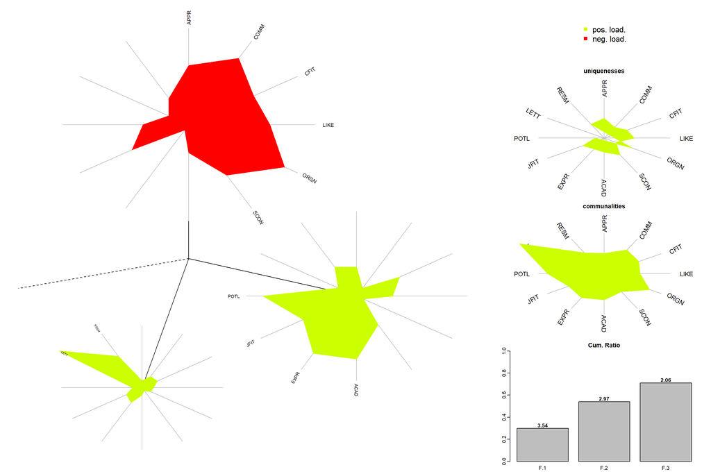

```r
##################################
# Formulating the dandelion plot to
# visualize both factor variances and loadings
# from the factor loading matrices
##################################
FA_PA_V_3F_FactorLoading <- factload(DPA.Descriptors.Numeric,
                                  cormeth = "pearson",
                                  method = "prax",
                                  nfac = 3,
                                  rotation = "varimax")

DandelionPlotPalette <- rev(rainbow(100, start = 0, end = 0.2))

dandelion(FA_PA_V_3F_FactorLoading,
          bound=0,
          mcex=c(1,1.2),
          palet=DandelionPlotPalette)
```

```r
##################################
# Conducting exploratory factor analysis
# using Principal Axes extraction
# and Varimax rotation
# with 4 factors
##################################
(FA_PA_V_4F <- fa(DPA.Descriptors.Numeric,
              nfactors = 4,
              fm="pa",
              rotate = "varimax",
              residuals=TRUE,
              SMC=TRUE,
              n.obs=nrow(DPA.Descriptors.Numeric)))
```

```
## Factor Analysis using method =  pa
## Call: fa(r = DPA.Descriptors.Numeric, nfactors = 4, n.obs = nrow(DPA.Descriptors.Numeric),
##     rotate = "varimax", residuals = TRUE, SMC = TRUE, fm = "pa")
## Standardized loadings (pattern matrix) based upon correlation matrix
##       PA1   PA2  PA4  PA3   h2   u2 com
## ACAD 0.71  0.18 0.27 0.16 0.64 0.36 1.5
## APPR 0.23  0.27 0.70 0.17 0.65 0.35 1.7
## COMM 0.12  0.76 0.31 0.21 0.73 0.27 1.5
## CFIT 0.52  0.65 0.15 0.19 0.76 0.24 2.2
## EXPR 0.73 -0.03 0.18 0.33 0.68 0.32 1.5
## JFIT 0.61  0.53 0.17 0.21 0.73 0.27 2.4
## LETT 0.23  0.25 0.06 0.88 0.89 0.11 1.3
## LIKE 0.23  0.32 0.69 0.19 0.66 0.34 1.8
## ORGN 0.09  0.84 0.36 0.09 0.86 0.14 1.4
## POTL 0.85  0.26 0.29 0.12 0.89 0.11 1.5
## RESM 0.28  0.13 0.33 0.83 0.88 0.12 1.6
## SCON 0.27  0.21 0.82 0.09 0.79 0.21 1.4
##
##                        PA1  PA2  PA4  PA3
## SS loadings           2.75 2.39 2.21 1.80
## Proportion Var        0.23 0.20 0.18 0.15
## Cumulative Var        0.23 0.43 0.61 0.76
## Proportion Explained  0.30 0.26 0.24 0.20
## Cumulative Proportion 0.30 0.56 0.80 1.00
##
## Mean item complexity =  1.7
## Test of the hypothesis that 4 factors are sufficient.
##
## The degrees of freedom for the null model are  66  and the objective function was  10.7 with Chi Square of  472.51
## The degrees of freedom for the model are 24  and the objective function was  1.47
##
## The root mean square of the residuals (RMSR) is  0.04
## The df corrected root mean square of the residuals is  0.06
##
## The harmonic number of observations is  50 with the empirical chi square  9.84  with prob <  1
## The total number of observations was  50  with Likelihood Chi Square =  60.87  with prob <  4.8e-05
##
## Tucker Lewis Index of factoring reliability =  0.732
## RMSEA index =  0.174  and the 90 % confidence intervals are  0.122 0.233
## BIC =  -33.02
## Fit based upon off diagonal values = 0.99
## Measures of factor score adequacy
##                                                    PA1  PA2  PA4  PA3
## Correlation of (regression) scores with factors   0.94 0.93 0.91 0.95
## Multiple R square of scores with factors          0.89 0.87 0.82 0.91
## Minimum correlation of possible factor scores     0.78 0.74 0.65 0.82
```

```r
(FA_PA_V_4F_Summary <- FA_PA_V_4F %>%
  model_parameters(sort = TRUE, threshold = "max"))
```

```
## # Rotated loadings from Factor Analysis (varimax-rotation)
##
## Variable | PA1  | PA2  | PA4  | PA3  | Complexity | Uniqueness
## --------------------------------------------------------------
## POTL     | 0.85 |      |      |      |    1.46    |    0.11
## EXPR     | 0.73 |      |      |      |    1.53    |    0.32
## ACAD     | 0.71 |      |      |      |    1.53    |    0.36
## JFIT     | 0.61 |      |      |      |    2.38    |    0.27
## ORGN     |      | 0.84 |      |      |    1.41    |    0.14
## COMM     |      | 0.76 |      |      |    1.55    |    0.27
## CFIT     |      | 0.65 |      |      |    2.22    |    0.24
## SCON     |      |      | 0.82 |      |    1.39    |    0.21
## APPR     |      |      | 0.70 |      |    1.67    |    0.35
## LIKE     |      |      | 0.69 |      |    1.84    |    0.34
## LETT     |      |      |      | 0.88 |    1.31    |    0.11
## RESM     |      |      |      | 0.83 |    1.62    |    0.12
##
## The 4 latent factors (varimax rotation) accounted for 76.28% of the total variance of the original data (PA1 = 22.93%, PA2 = 19.92%, PA4 = 18.41%, PA3 = 15.03%).
```

```r
summary(FA_PA_V_4F_Summary)
```

```
## # (Explained) Variance of Components
##
## Parameter                       |   PA1 |   PA2 |   PA4 |   PA3
## ---------------------------------------------------------------
## Eigenvalues                     | 6.152 | 1.259 | 0.943 | 0.800
## Variance Explained              | 0.229 | 0.199 | 0.184 | 0.150
## Variance Explained (Cumulative) | 0.229 | 0.429 | 0.613 | 0.763
## Variance Explained (Proportion) | 0.301 | 0.261 | 0.241 | 0.197
```

```r
##################################
# Extracting the residuals
# from the Exploratory Factor Analysis
##################################
(FA_PA_V_4F_Residual <- residuals(FA_PA_V_4F,
                              diag=FALSE,
                              na.rm=TRUE))
```

```
##      ACAD  APPR  COMM  CFIT  EXPR  JFIT  LETT  LIKE  ORGN  POTL  RESM
## ACAD    NA
## APPR  0.04    NA
## COMM  0.07  0.01    NA
## CFIT -0.06 -0.02 -0.05    NA
## EXPR  0.05 -0.03  0.01 -0.05    NA
## JFIT -0.07 -0.03 -0.07  0.15 -0.01    NA
## LETT -0.03 -0.01 -0.01  0.00  0.02  0.00    NA
## LIKE -0.03 -0.02 -0.03  0.02 -0.03  0.07  0.02    NA
## ORGN  0.03  0.02  0.08 -0.05  0.04 -0.06  0.01 -0.03    NA
## POTL  0.05  0.03  0.01 -0.02  0.00 -0.03  0.01 -0.01  0.01    NA
## RESM  0.02  0.03  0.02  0.01 -0.01 -0.01  0.00 -0.01 -0.03 -0.01    NA
## SCON -0.06 -0.01 -0.03  0.04  0.04  0.03 -0.01  0.05 -0.01 -0.03 -0.01
## [1]    NA
```

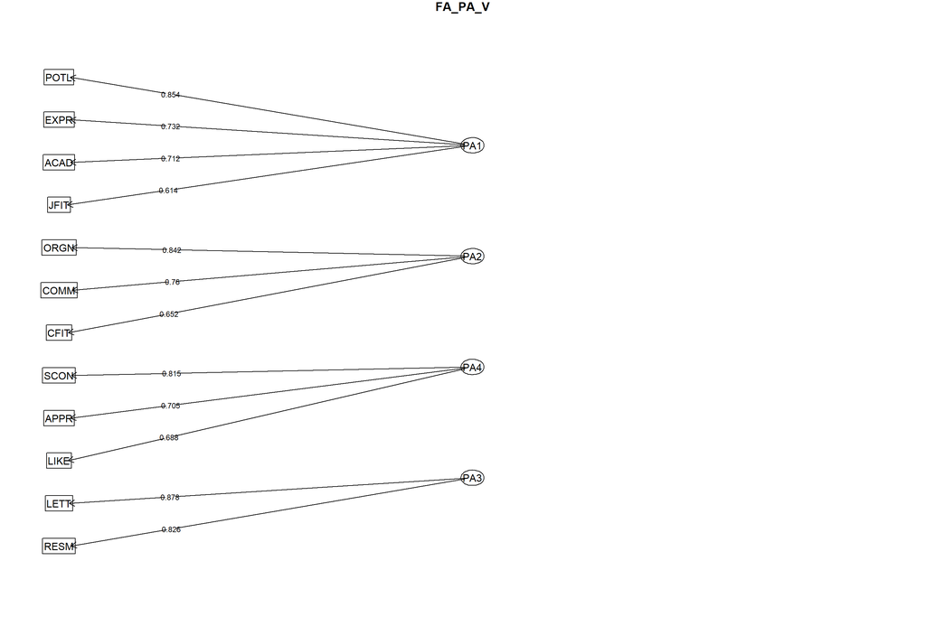

```r
##################################
# Graph the factor loading matrices
##################################
fa.diagram(FA_PA_V_4F,
           sort=TRUE,
           cut=0,
           digits=3,
           main="FA_PA_V",
           cex=0.75)
```

```r
##################################
# computing the internal consistency
# measure of reliability using the
# Cronbach's alpha coefficient
# for each factor
##################################
alpha(DPA.Descriptors.Numeric[,c("POTL","EXPR","ACAD","JFIT")])
```

```
##
## Reliability analysis
## Call: alpha(x = DPA.Descriptors.Numeric[, c("POTL", "EXPR", "ACAD",
##     "JFIT")])
##
##   raw_alpha std.alpha G6(smc) average_r S/N   ase mean  sd median_r
##       0.88      0.88    0.87      0.66 7.6 0.028  7.3 1.2     0.69
##
##     95% confidence boundaries
##          lower alpha upper
## Feldt     0.81  0.88  0.93
## Duhachek  0.82  0.88  0.93
##
##  Reliability if an item is dropped:
##      raw_alpha std.alpha G6(smc) average_r S/N alpha se  var.r med.r
## POTL      0.79      0.80    0.74      0.58 4.1    0.051 0.0063  0.54
## EXPR      0.86      0.86    0.84      0.68 6.4    0.036 0.0169  0.71
## ACAD      0.84      0.84    0.80      0.64 5.4    0.040 0.0111  0.70
## JFIT      0.89      0.89    0.85      0.72 7.8    0.028 0.0043  0.70
##
##  Item statistics
##       n raw.r std.r r.cor r.drop mean  sd
## POTL 50  0.93  0.93  0.92   0.87  7.3 1.4
## EXPR 50  0.83  0.84  0.75   0.71  7.3 1.4
## ACAD 50  0.86  0.87  0.83   0.76  7.4 1.3
## JFIT 50  0.82  0.80  0.71   0.65  7.0 1.6
##
## Non missing response frequency for each item
##         3    4    5    6    7    8    9   10 miss
## POTL 0.00 0.04 0.06 0.18 0.22 0.30 0.18 0.02    0
## EXPR 0.00 0.00 0.10 0.20 0.24 0.24 0.18 0.04    0
## ACAD 0.00 0.02 0.02 0.22 0.28 0.24 0.18 0.04    0
## JFIT 0.06 0.00 0.06 0.22 0.26 0.24 0.12 0.04    0
```

```r
alpha(DPA.Descriptors.Numeric[,c("ORGN","COMM","CFIT")])
```

```
##
## Reliability analysis
## Call: alpha(x = DPA.Descriptors.Numeric[, c("ORGN", "COMM", "CFIT")])
##
##   raw_alpha std.alpha G6(smc) average_r S/N   ase mean  sd median_r
##       0.87      0.87    0.85      0.69 6.7 0.034  6.9 1.4     0.62
##
##     95% confidence boundaries
##          lower alpha upper
## Feldt     0.79  0.87  0.92
## Duhachek  0.80  0.87  0.93
##
##  Reliability if an item is dropped:
##      raw_alpha std.alpha G6(smc) average_r  S/N alpha se var.r med.r
## ORGN      0.74      0.74    0.59      0.59  2.9    0.073    NA  0.59
## COMM      0.77      0.77    0.62      0.62  3.3    0.066    NA  0.62
## CFIT      0.92      0.93    0.86      0.86 12.5    0.021    NA  0.86
##
##  Item statistics
##       n raw.r std.r r.cor r.drop mean  sd
## ORGN 50  0.93  0.93  0.91   0.83  6.9 1.6
## COMM 50  0.91  0.92  0.89   0.80  6.9 1.5
## CFIT 50  0.84  0.83  0.65   0.63  6.9 1.6
##
## Non missing response frequency for each item
##         3    4    5    6    7    8    9   10 miss
## ORGN 0.02 0.04 0.20 0.10 0.24 0.24 0.16 0.00    0
## COMM 0.04 0.04 0.06 0.20 0.30 0.28 0.06 0.02    0
## CFIT 0.02 0.06 0.16 0.12 0.22 0.30 0.08 0.04    0
```

```r
alpha(DPA.Descriptors.Numeric[,c("SCON","APPR","LIKE")])
```

```
##
## Reliability analysis
## Call: alpha(x = DPA.Descriptors.Numeric[, c("SCON", "APPR", "LIKE")])
##
##   raw_alpha std.alpha G6(smc) average_r S/N   ase mean   sd median_r
##       0.87      0.87    0.83       0.7 6.9 0.031  7.4 0.99      0.7
##
##     95% confidence boundaries
##          lower alpha upper
## Feldt     0.80  0.87  0.92
## Duhachek  0.81  0.87  0.93
##
##  Reliability if an item is dropped:
##      raw_alpha std.alpha G6(smc) average_r S/N alpha se var.r med.r
## SCON      0.78      0.78    0.64      0.64 3.5    0.062    NA  0.64
## APPR      0.86      0.86    0.75      0.75 6.1    0.040    NA  0.75
## LIKE      0.82      0.82    0.70      0.70 4.6    0.051    NA  0.70
##
##  Item statistics
##       n raw.r std.r r.cor r.drop mean  sd
## SCON 50  0.92  0.91  0.86   0.80  7.3 1.2
## APPR 50  0.86  0.87  0.76   0.71  7.4 1.0
## LIKE 50  0.90  0.89  0.82   0.76  7.4 1.1
##
## Non missing response frequency for each item
##         4    5    6    7    8    9   10 miss
## SCON 0.00 0.08 0.14 0.32 0.28 0.18 0.00    0
## APPR 0.00 0.02 0.16 0.32 0.38 0.10 0.02    0
## LIKE 0.02 0.04 0.12 0.32 0.36 0.14 0.00    0
```

```r
alpha(DPA.Descriptors.Numeric[,c("LETT","RESM")])
```

```
##
## Reliability analysis
## Call: alpha(x = DPA.Descriptors.Numeric[, c("LETT", "RESM")])
##
##   raw_alpha std.alpha G6(smc) average_r S/N   ase mean  sd median_r
##       0.91      0.91    0.84      0.84  10 0.025  7.2 1.6     0.84
##
##     95% confidence boundaries
##          lower alpha upper
## Feldt     0.84  0.91  0.95
## Duhachek  0.86  0.91  0.96
##
##  Reliability if an item is dropped:
##      raw_alpha std.alpha G6(smc) average_r S/N alpha se var.r med.r
## LETT      0.83      0.84     0.7      0.84 5.1       NA     0  0.84
## RESM      0.84      0.84     0.7      0.84 5.1       NA     0  0.84
##
##  Item statistics
##       n raw.r std.r r.cor r.drop mean  sd
## LETT 50  0.96  0.96  0.88   0.84  7.2 1.7
## RESM 50  0.96  0.96  0.88   0.84  7.2 1.7
##
## Non missing response frequency for each item
##         4    5    6    7    8    9   10 miss
## LETT 0.06 0.12 0.14 0.22 0.24 0.12 0.10    0
## RESM 0.08 0.06 0.22 0.18 0.16 0.24 0.06    0
```

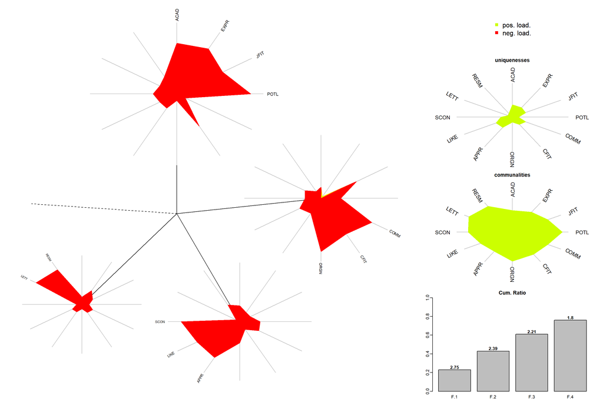

```r
##################################
# Formulating the dandelion plot to
# visualize both factor variances and loadings
# from the factor loading matrices
##################################
FA_PA_V_4F_FactorLoading <- factload(DPA.Descriptors.Numeric,
                                  cormeth = "pearson",
                                  method = "prax",
                                  nfac = 4,
                                  rotation = "varimax")

DandelionPlotPalette <- rev(rainbow(100, start = 0, end = 0.2))

dandelion(FA_PA_V_4F_FactorLoading,
          bound=0,
          mcex=c(1,1.2),
          palet=DandelionPlotPalette)
```